# Uncertainty, Probability, and Monte Carlo

Lecture 08

September 23, 2026

# Review of Last Class

## Dissolved Oxygen and Streeter-Phelps

- **Dissolved Oxygen**: Critical for aquatic life/ecosystem health
- Depleted by decomposition of organic matter/waste, often regulated
- Derived Streeter-Phelps equation: produces **sag curve** due to competition between reaeration and decomposition of CBOD and NBOD.

## Questions?

[figure not shown]

**Text**: VSRIKRISH to 22333

**URL**: https://pollev.com/vsrikrish  
[See Results](https://www.polleverywhere.com/multiple_choice_polls/qKeig0hHShZYHAOmvZtZm?preview=true&controls=none)

# Uncertainty and Probability

## Where Does Uncertainty Come From?

Uncertainty can come from several sources:

- Stochastic models (internal randomness)
- Uncertain external conditions (forcings)
- Uncertain parameters
- Uncertain model dynamics from different specifications/neglecting processes

## Two Kinds of Uncertainty

- **Aleatory** uncertainty: “Truly” random processes/fluctuations.
- **Epistemic** uncertainty: From lack of knowledge.

[figure not shown]

Aleatory vs epistemic uncertainty

Source: [XKCD 2440](https://xkcd.com/2440/)

## Aleatory vs. Epistemic Examples

Would more data or study reduce the uncertainty? If so, it is **epistemic**. If it is unpredictable randomness, it is **aleatory**.

| Aleatory | Epistemic |
| --- | --- |
| The next roll of a die | Whether the die is loaded |
| When your light bulb fails | The bulb model’s lifespan |
| Next spring’s peak flow | The 100-year flood |
| Tomorrow’s commute traffic | Next week’s quiz questions |

## Random Variables

A **random variable** is a quantity whose value we do not know. Its **distribution** describes how plausible each possible value is.

**Discrete**: values you can list, like storms per year.

**Probability mass function**: $p(x) = \mathbb{P}(X = x)$

**Continuous**: any value in a range, like CBOD load.

**Probability density function**: $\mathbb{P}(a < X < b) = \int_a^b f(x)\,dx$

## What Is a Probability Distribution?

A **probability distribution** assigns probabilities to the possible outcomes of a random variable, following three rules:

1. $\mathbb{P}(A) \geq 0$ for any event $A$
2. $\mathbb{P}(\text{some outcome occurs}) = 1$
3. $\mathbb{P}(A \cup B) = \mathbb{P}(A) + \mathbb{P}(B)$ if $A$ and $B$ cannot both happen

**Notation**: $X \sim \mathcal{D}$ means $X$ follows $\mathcal{D}$, e.g. $B_0 \sim \mathcal{N}(9, 1.5^2)$.

## Density and Cumulative Probability

A probability distribution $\mathcal{D}$ is described using two equivalent specifications:

- **Probability Density Function (PDF)** $f_\mathcal{D}(x)$: how concentrated is the probability at $x$.
- **Cumulative Distribution Function (CDF)** $F_\mathcal{D}(x) = \int_{-\infty}^x f_\mathcal{D}(u)\,du$: what is the total probability *at or below* $x$.

## CDF vs. PDF

```julia
example_dist = TDist(4)
x_values = -5:0.01:5
level = 0.25
cut = quantile(example_dist, level)

p_pdf = plot(x_values, pdf.(example_dist, x_values), color=:black, linewidth=4,
    xlabel=L"x", ylabel="Density", legend=false)
shaded = -5:0.01:cut
plot!(p_pdf, shaded, pdf.(example_dist, shaded), fillrange=zeros(length(shaded)),
    fillalpha=0.35, color=cb_blue, linewidth=0)

p_cdf = plot(x_values, cdf.(example_dist, x_values), color=:black, linewidth=4,
    xlabel=L"x", ylabel="Cumulative probability", legend=false)
plot!(p_cdf, [-5, cut], [level, level], color=cb_vermillion, linewidth=3, linestyle=:dash)
plot!(p_cdf, [cut, cut], [0, level], color=cb_vermillion, linewidth=3, linestyle=:dash)

plot(p_pdf, p_cdf, layout=(1, 2), size=(1200, 450), left_margin=10mm,
    bottom_margin=10mm)
```

[figure not shown]

Figure 1: The shaded area under the density is the height of the cumulative curve. Both panels show the same quarter of the probability.

## Quantiles

The **quantile function** is the inverse of the CDF:

$$q(\alpha) = F^{-1}_\mathcal{D}(\alpha), \qquad\text{so}\qquad x_0 = q(\alpha) \iff \mathbb{P}(X \leq x_0) = \alpha.$$

- CDF: for a given $x_0$, what is $\mathbb{P}(X \leq x_0)$?
- Quantile: for a given $0 \leq \alpha \leq 1$, what value $x_0$ has $\mathbb{P}(X \leq x_0) = \alpha$?

## Independence

Two events are **independent** if knowing one happened tells you nothing about the other:

$$\mathbb{P}(A \cap B) = \mathbb{P}(A)\,\mathbb{P}(B)$$

## Expectation and Variance

$$\begin{aligned}
\mathbb{E}[X] &= \int x f(x)\,dx \\
\text{Var}(X) &= \mathbb{E}\left[(X - \mathbb{E}[X])^2\right]
\end{aligned}$$

## Rules for Expectation and Variance

For constants $a$ and $b$ and random variables $X$ and $Y$:

$$\begin{aligned}
\mathbb{E}[aX + b] &= a\,\mathbb{E}[X] + b \\
\text{Var}(aX + b) &= a^2\,\text{Var}(X) \\
\mathbb{E}[X + Y] &= \mathbb{E}[X] + \mathbb{E}[Y] \\
\end{aligned}$$

If $X$ and $Y$ are independent:
$$\text{Var}(X + Y) = \text{Var}(X) + \text{Var}(Y)$$

## The Average of a Function Is Not the Function of the Average

$$\mathbb{E}[h(B_0)] = h(\mathbb{E}[B_0])\ \text{if and only if}\ h\ \text{is linear}.$$

**Which of these do we want**?

## Distributions Are Assumptions

**Specifying a distribution is making an assumption about the probability model producing observations.**

There are defaults. If your data is:

- Continuous and fat-tailed? **Cauchy distribution**
- Continuous and bounded? **Beta distribution**
- Sums of positive random variables? **Gamma or Normal distribution**

## Common Distributions

| Distribution | Use it when |
| --- | --- |
| Uniform | Every value in a range equally likely |
| Normal | Symmetric about a typical value |
| LogNormal | Positive and right-skewed |
| Bernoulli | A yes/no event |

## Selecting a Distribution

A distribution implicitly answers questions like:

- What is the most probable event? How much more likely is it than the others?
- Are larger or smaller events more, less, or equally probable?
- How probable are extreme events?
- Are different events correlated, or are they independent?

## Distribution Tails

The tails represent the probability of high-impact outcomes.

**Small changes to these (low) probabilities can greatly influence risk.**

```julia
x = range(-5, 10, length=200)
p_tails = plot(x, pdf.(Cauchy(), x), linewidth=3, color=cb_vermillion,
    linestyle=:dash, yaxis=false, yticks=false, label="Cauchy", xlabel="Value",
    legend=:topright)
plot!(p_tails, x, pdf.(Normal(), x), linewidth=3, color=cb_blue, label="Normal")
xf = x[x.>1.75]
plot!(p_tails, xf, pdf.(Cauchy(), xf), fillrange=pdf.(Normal(), xf),
    fillcolor=cb_vermillion, fillalpha=0.25, label=nothing, linecolor=nothing)
plot!(p_tails, size=(550, 420), left_margin=10mm, bottom_margin=10mm)
```

[figure not shown]

Figure 2: Comparison of Cauchy and Normal tails.

## “What Distribution Should I Use?”

**There is no right answer, no matter what a statistical test tells you.**

- What assumptions are justifiable? Think about tails, symmetry, skew.
- What information do you actually have?

## Choosing $B_0$’s Distribution

For the CBOD load: not too far from a typical value, symmetric-ish, occasionally larger or smaller by a moderate amount, never negative in reality (though the Normal doesn’t know that).

$$B_0 \sim \mathcal{N}(9,\ 1.5^2)\ \text{mg/L}$$

Perhaps use a truncated Normal to eliminate possibility of negatives.

## Standards Are Written as Probabilities

Design and regulatory standards are almost never stated as “never fails.” They are usually stated as frequencies.

For example:

Levees in the United States are supposed to only fail at “once in 100 years” — or, equivalently, to have at most a **1% chance of failure in any given year**.

## Exceedance Probability

The probability that a quantity is **worse than** some threshold $x^*$:

$$p = \mathbb{P}(X > x^*) = 1 - F_\mathcal{D}(x^*)$$

It is the complement of the CDF.

## Return Periods

The **return period** is its reciprocal:

$$T = \frac{1}{p}$$

A 1% annual exceedance probability is a 100-year event. The two say exactly the same thing in different units.

## How Often Does An Extreme Occur?

A “100-year event” does **not** mean one per century, or that you are safe for 99 years after one happens.

If years are independent, the chance of *at least one* in a 30-year design life is
$$1 - (1 - 0.01)^{30} \approx 26\%.$$
Better than one in four, over the life of the structure.

## What a Return Period Assumes

- Each year is an **independent** draw.
- The distribution is **not changing** — the same $F$ next decade as last.
- If it is changing, the return period is **conditional** on the scenario driving the change.

## Where Would We Get $F$?

Exceedance probability is $1 - F(x^*)$. That is easy when you know $F$.

For many systems, you do not. Outcomes of interest may be the output of a non-linear system with multiple inputs.

In that case, we need a simulation-based approach to estimate expectations or exceedance probabilities.

# Monte Carlo Simulation

## What Is Monte Carlo?

**Monte Carlo simulation**: propagate random samples through a model to estimate a value — usually an expectation or a probability.

[figure not shown]

## The Monte Carlo Principle

**Goal**: estimate $\mathbb{E}_f[h(x)]$ for $x \sim f(x)$.

Sample $x^1, \ldots, x^N \sim f(x)$ and estimate

$$\mathbb{E}_f[h(x)] = \int_{x\in X} h(x)f(x)\,dx \approx \frac{1}{N}\sum_{n=1}^N h(x^n)$$

A probability is just a special case: $h(x) = \mathbb{1}[\text{event}]$, and the average becomes a frequency.

## Example: Estimating $\pi$

Sample points uniformly in a square; the fraction landing in the inscribed circle estimates

$$\frac{\text{Area of Circle}}{\text{Area of Square}} = \frac{\pi}{4}$$

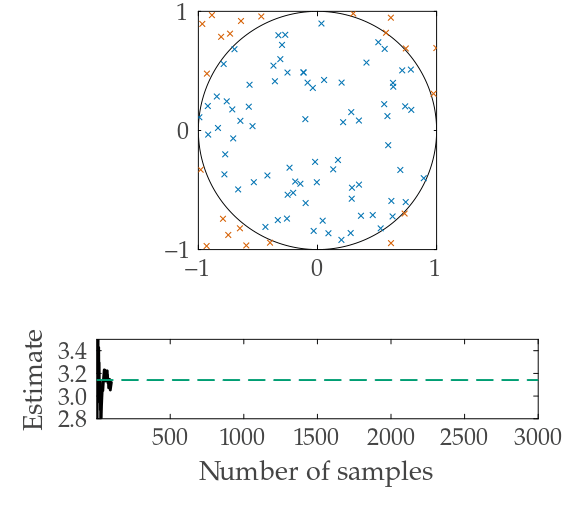

Figure 3: Points are revealed 100 at a time. Blue land inside the circle, vermillion outside, and the estimate settles toward π (dashed).

```julia
using Logging

Random.seed!(4750)
sample_count = 3000
points = rand(Uniform(-1, 1), (sample_count, 2))
inside = [points[i, 1]^2 + points[i, 2]^2 < 1 for i in 1:sample_count]
running_estimate = [4 * mean(inside[1:i]) for i in 1:sample_count]

circle_angles = range(0, 2π, length=500)
batch_size = 100

# Each frame redraws everything drawn so far, 100 more samples at a time.
animation = @animate for shown_count in batch_size:batch_size:sample_count
    shown_points = points[1:shown_count, :]
    shown_inside = inside[1:shown_count]

    p_square = plot(cos.(circle_angles), sin.(circle_angles), color=:black, linewidth=1,
        xlims=(-1, 1), ylims=(-1, 1), xticks=[-1, 0, 1], yticks=[-1, 0, 1],
        aspect_ratio=1, legend=false)
    scatter!(p_square, shown_points[shown_inside, 1], shown_points[shown_inside, 2],
        color=cb_blue, markershape=:x, markersize=3)
    scatter!(p_square, shown_points[.!shown_inside, 1], shown_points[.!shown_inside, 2],
        color=cb_vermillion, markershape=:x, markersize=3)

    p_estimate = plot(1:shown_count, running_estimate[1:shown_count], color=:black,
        linewidth=3, xlims=(1, sample_count), ylims=(2.8, 3.5), legend=false,
        xlabel="Number of samples", ylabel="Estimate")
    hline!(p_estimate, [π], color=cb_green, linestyle=:dash, linewidth=2)

    plot(p_square, p_estimate, layout=grid(2, 1, heights=[3/4, 1/4]), size=(600, 550),
        right_margin=8mm)
end

# gif() prints a "saved animation" message; this keeps it off the slide.
Logging.disable_logging(Logging.Info)
gif(animation, "figures/mc_pi.gif", fps=2)
```

# How Uncertain is the Estimate?

## Monte Carlo Estimates Are Random

$Y_i$ is a random sample, so $\tilde{\mu}_n = \frac{1}{n}\sum_{i=1}^n Y_i$ is a random variable.

This raises the question: **on average**, how right or wrong is the estimate?

**Bias** of a statistic $T$ used to estimate a “true” value $T_0$: $\mathbb{E}[T] - T_0$.

## The MC Estimate Is Unbiased

Provided the mean of $Y$ exists and its variance is finite,

$$\mathbb{E}[\tilde{\mu}_n] = \frac{1}{n}\sum_{i=1}^n \mathbb{E}[Y_i] = \frac{1}{n}\, n\, \mu = \mu.$$

Averaged over many *sets* of samples, the estimate is correct. That is a statement about the **procedure**, not about the run you just did.

## Monte Carlo Convergence

What are the convergence properties of any given MC run?

If $Y$ is a random variable whose expectation exists, and $Y_1, \ldots, Y_n$ are independent and identically distributed, then by the **weak law of large numbers**

$$\lim_{n \to \infty} \mathbb{P}\left(\left|\tilde{\mu}_n - \mu\right| \leq \varepsilon\right) = 1$$

for any $\varepsilon > 0$.

## Monte Carlo Error

The variance of the estimator is

$$\text{Var}(\tilde\mu_n) = \frac{\sigma_Y^2}{n} \qquad\Longrightarrow\qquad \text{standard error } \tilde\sigma_n = \frac{\sigma_Y}{\sqrt{n}}$$

In practice: replace $\sigma_Y$ with the sample standard deviation $\sqrt{\text{Var}(Y_i)}$.

## Implications of Monte Carlo Error

**To cut the error by 10×, you need 100× more samples.** Monte Carlo error shrinks at order $1/\sqrt{n}$.

> Monte Carlo is an extremely bad method. It should only be used when all alternative methods are worse.

— Sokal, *Monte Carlo Methods in Statistical Mechanics*, 1996

# Key Takeaways and Upcoming Schedule

## Key Takeaways

- Uncertainty comes from stochastic models, forcings, parameters, and model structure itself — and **choosing a distribution is a modeling assumption**, not a neutral default.
- **The average outcome is not the outcome at the average input.** For a nonlinear model those differ, which is why we sample rather than run once at the mean.
- An exceedance probability is $1 - F(x^*)$, and a return period is its reciprocal. Neither means “once per century.”
- Monte Carlo estimates are **unbiased** and the law of large numbers says they converge — but the standard error shrinks only as $1/\sqrt{n}$.

## Next Classes

**Monday**: Confidence intervals, then applying Monte Carlo to the DO model and how to justify a sample size for your own work.

The probability tutorial covers today’s review in more depth, with Julia examples.

## Assessments

**Homework 3**: Due tomorrow at 9pm.

**Mini-Project 1**: Assigned today, due Thursday, October 22.